# Esercitazione N.5

Nonlinearità: interazioni

Autore/Autrice

Andrea Recine

Data di Pubblicazione

5 maggio 2026

## 1 Setup

```r
library(tidyverse)
library(knitr)
library(modelsummary)
library(fixest)
library(wooldridge)
data("wage1", package = "wooldridge")
```

## 2 Introduzione

In questa esercitazione vedremo come interpretare i coefficienti di interazione tra due variabili dummy, tra una variabile dummy e una variabile continua e tra due variabili continue. L’interazione tra variabili consente di modellare situazioni in cui l’effetto di una variabile dipende dal livello di un’altra variabile.

Riprendiamo un esercizio precedente in cui abbiamo interpretato i coefficienti di variabili dummy con categorie multiple. Abbiamo creato 3 dummy (donne sposate, uomini sposati e donne single, cioè non sposate) e interpretato i coefficienti rispetto agli uomini single (non sposati), la nostra categoria omessa:

```r
wage1 <- wage1 %>%
  mutate(
    marrmale = ifelse(female == 0 & married == 1, 1, 0),
    marrfemale = ifelse(female == 1 & married == 1, 1, 0),
    singfem = ifelse(female == 1 & married == 0, 1, 0)
  )
```

Per semplicità e confronto con la regressione con interazione tra $female$ e $married$ (che vedremo tra poco) stimiamo un modello di regressione con queste tre variabili dummy senza controllare per altri fattori come anni di istruzione, esperienza lavorativa…

```r
reg_wage_sm1 <- feols(wage ~ marrmale + marrfemale + singfem, data = wage1, vcov = "hetero")
modelsummary(list("Wage" = reg_wage_sm1), gof_omit = "AIC|BIC|RMSE|R2 Adj.")
```

|  | Wage |
| --- | --- |
| (Intercept) | 5.168 |
|  | (0.293) |
| marrmale | 2.815 |
|  | (0.435) |
| marrfemale | -0.602 |
|  | (0.342) |
| singfem | -0.556 |
|  | (0.401) |
| Num.Obs. | 526 |
| R2 | 0.181 |

Come si interpretano i coefficienti?

1. L’intercetta rappresenta il salario orario medio predetto in dollari della categoria omessa (**uomini single**). Il valore atteso di $wage$ quando $marrmale$, $marrfemale$ e $singfem$ sono uguali a zero.
2. $marrmale$: in media gli uomini sposati guadagnano 2.815 dollari in più rispetto agli uomini single.
3. $marrfemale$: in media le donne sposate guadagnano 0.60 dollari all’ora in meno rispetto agli uomini single.
4. $singfem$: in media le donne single guadagnano 0.55 dollari all’ora in meno rispetto agli uomini single.

**Nota:** non stiamo controllando per anni di istruzione, anni di esperienza…

## 3 Interazione tra due variabili dummy

Ora creiamo l’interazione tra due variabili dummy: $female$ e $married$. Ciò consente di vedere se il “ritorno” del matrimonio dipende dal genere.

**NotaSpecificare le interazioni con `fixest`**

In `fixest` è possibile specificare le interazioni in modo più compatto usando l’operatore `*` che include automaticamente i termini principali e il termine di interazione. Quindi:

```r
reg_wage_marrfe <- feols(wage ~ female * married, data = wage1, vcov = "hetero")
```

Se invece si volesse specificare solo il termine di interazione senza i termini principali, si potrebbe usare l’operatore `:` come segue:

```r
reg_wage_marrfe <- feols(wage ~ female + married + female:married, data = wage1, vcov = "hetero")
```

Questi due comandi producono lo stesso modello di regressione.

```r
reg_wage_marrfe <- feols(wage ~ female * married, data = wage1, vcov = "hetero")
modelsummary(list("Wage" = reg_wage_marrfe), gof_omit = "AIC|BIC|RMSE|R2 Adj.")
```

|  | Wage |
| --- | --- |
| (Intercept) | 5.168 |
|  | (0.293) |
| female | -0.556 |
|  | (0.401) |
| married | 2.815 |
|  | (0.435) |
| female × married | -2.861 |
|  | (0.543) |
| Num.Obs. | 526 |
| R2 | 0.181 |

I risultati della regressione mostrano che l’interazione tra genere e stato coniugale è statisticamente significativa (calcolate il valore critico).

Coefficiente di $female$ rappresenta la differenza salariale tra donne e uomini non sposati. In media le donne non sposate guadagnano 0.556 dollari all’ora in meno rispetto agli uomini non sposati.

Coefficiente di $married$ rappresenta l’effetto del matrimonio sul salario orario degli **uomini**. In media gli uomini sposati guadagnano 2.815 dollari all’ora in più rispetto agli uomini non sposati (single).

Coefficiente dell’interazione $female \times married$ rappresenta la differenza nell’effetto del matrimonio tra donne e uomini. L’effetto del matrimonio sul salario orario è 2.861 dollari inferiore per le donne rispetto agli uomini.

In media le donne sposate guadagnano 0.046 dollari in meno rispetto alle donne non sposate ($2.815 - 2.861 = -0.046$).

**NotaNota**

**Possiamo usare la regressione stimata per stimare il salario medio orario per ciascuna delle quattro combinazioni possibili:**

- L’intercetta uguale a 5.168 rappresenta il salario orario medio per gli uomini single (non sposati) cioè quando $female$ = 0 e $married$ = 0.
- Considerando $female$ = 0 e $married$ = 1 otteniamo 7.983 (5.168 + 2.815) che rappresenta il salario orario medio in dollari degli uomini sposati.
- Quando $female$ = 1 e $married$ = 0 otteniamo 4.612 (5.168 - 0.556), che rappresenta il salario orario medio delle donne single (non sposate).
- Quando $female$ = 1 e $married$ = 1 otteniamo 4.566 (5.168 - 0.556 + 2.815 - 2.861), cioè salario orario medio delle donne sposate.

**Nota:** non stiamo controllando per altri fattori come anni di istruzione…

### 3.1 Interazione $male$ e $married$

Creiamo una nuova variabile dummy $male$ che è uguale a 1 per gli uomini e 0 per le donne.

```r
wage1 <- wage1 %>%
  mutate(male = 1 - female)
```

```r
reg_wage_marrmal <- feols(wage ~ male * married, data = wage1, vcov = "hetero")
modelsummary(list("Wage (Female = 1)" = reg_wage_marrfe, "Wage (Male = 1)" = reg_wage_marrmal), gof_omit = "AIC|BIC|RMSE|R2 Adj.")
```

|  | Wage (Female = 1) | Wage (Male = 1) |
| --- | --- | --- |
| (Intercept) | 5.168 | 4.612 |
|  | (0.293) | (0.273) |
| female | -0.556 |  |
|  | (0.401) |  |
| married | 2.815 | -0.046 |
|  | (0.435) | (0.325) |
| female × married | -2.861 |  |
|  | (0.543) |  |
| male |  | 0.556 |
|  |  | (0.401) |
| male × married |  | 2.861 |
|  |  | (0.543) |
| Num.Obs. | 526 | 526 |
| R2 | 0.181 | 0.181 |

In questo caso (seconda colonna della regressione) il coefficiente di $married$ rappresenta l’effetto del matrimonio sul salario orario per le donne. In media le donne sposate guadagnano 0.046 dollari all’ora in meno rispetto alle donne non sposate.

Coefficiente di $male$ rappresenta la differenza salariale tra uomini e donne non sposati. In media gli uomini non sposati guadagnano 0.556 dollari all’ora in più rispetto alle donne non sposate.

L’intercetta rappresenta il salario medio per le donne single (non sposate) cioè quando $male$ = 0 e $married$ = 0.

Coefficiente dell’interazione $male \times married$ rappresenta la differenza nell’effetto del matrimonio tra uomini e donne. L’effetto del matrimonio sul salario orario è 2.861 dollari maggiore per gli uomini rispetto alle donne.

## 4 Interazione tra variabile dummy e continua

In questa esercitazione consideriamo il caso che il libro (Stock e Watson p. 220) definisce pendenze e intercette diverse. Quindi includiamo le variabili $educ$, $female$ e la loro interazione.

```r
# Primo modello: regressione di wage su educ, female e la loro interazione
reg_wage_educfe <- feols(wage ~ educ * female, data = wage1, vcov = "hetero")


# Risultati
modelsummary(list("Wage" = reg_wage_educfe), gof_omit = "AIC|BIC|RMSE|R2 Adj.")
```

|  | Wage |
| --- | --- |
| (Intercept) | 0.200 |
|  | (0.872) |
| educ | 0.539 |
|  | (0.073) |
| female | -1.199 |
|  | (1.461) |
| educ × female | -0.086 |
|  | (0.124) |
| Num.Obs. | 526 |
| R2 | 0.260 |

- Coefficiente di $educ$ rappresenta l’effetto di un anno aggiuntivo di istruzione sul salario per gli uomini (quando $female$ = 0). L’effetto di un anno aggiuntivo di istruzione per gli uomini è pari a 0.539 dollari all’ora.
- Coefficiente di $female$ rappresenta la differenza salariale tra donne e uomini con zero anni di istruzione ($educ$ = 0).
- Coefficiente di $educ \times female$ rappresenta la differenza nell’effetto dell’istruzione tra donne e uomini. Le donne ricevono un “premio” per l’istruzione inferiore di circa 0.086 dollari all’ora rispetto agli uomini.
- L’effetto di un anno aggiuntivo di istruzione per le donne è pari a $\beta_1 + \beta_3$ cioè $0.539 - 0.086 = 0.453$ dollari.

E infatti $0.453 - 0.539 = -0.086$ è esattamente il coefficiente di interazione.

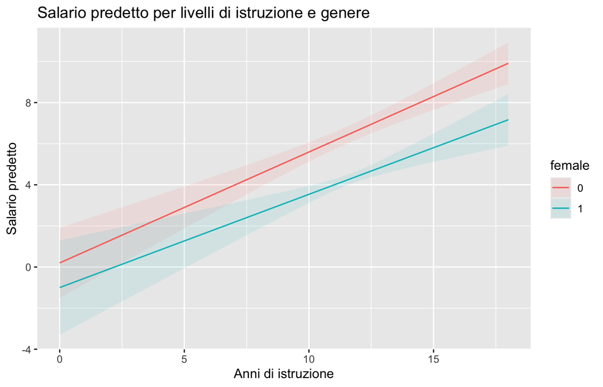

```r
# install.packages("marginaleffects")
library(marginaleffects)
plot_predictions(reg_wage_educfe,
                condition = c("educ", "female")) +
  labs(title = "Salario predetto per livelli di istruzione e genere",
       x = "Anni di istruzione",
       y = "Salario predetto")
```

Il grafico mostra che il salario predetto aumenta con gli anni di istruzione sia per uomini che per donne, ma la pendenza è più ripida per gli uomini rispetto alle donne (anche se non è una differenza molto grande).

## 5 Interazione tra due variabili continue

Consideriamo l’interazione tra $educ$ e $exper$ per vedere se l’effetto di un anno aggiuntivo di istruzione sul salario dipende dagli anni di esperienza lavorativa (o anche viceversa).

```r
reg_wage_educexper <- feols(wage ~ educ * exper, data = wage1, vcov = "hetero")

reg_wage_educexper2 <- feols(wage ~ educ * exper + female + tenure, data = wage1, vcov = "hetero")
# Risultati
modelsummary(list("Wage" = reg_wage_educexper, "Wage" = reg_wage_educexper2), gof_omit = "AIC|BIC|RMSE|R2 Adj.")
```

|  | Wage | Wage |
| --- | --- | --- |
| (Intercept) | -2.860 | -0.700 |
|  | (1.069) | (1.170) |
| educ | 0.602 | 0.503 |
|  | (0.087) | (0.090) |
| exper | 0.046 | -0.013 |
|  | (0.036) | (0.040) |
| educ × exper | 0.002 | 0.003 |
|  | (0.003) | (0.003) |
| female |  | -1.841 |
|  |  | (0.265) |
| tenure |  | 0.140 |
|  |  | (0.028) |
| Num.Obs. | 526 | 526 |
| R2 | 0.226 | 0.365 |

- Coefficiente associato a $educ$ rappresenta l’effetto marginale di un anno aggiuntivo di istruzione sul salario quando l’esperienza ($exper$) è zero.
- Coefficiente di $exper$ rappresenta l’effetto marginale di un anno aggiuntivo di esperienza sul salario quando l’istruzione ($educ$) è zero.

Il coefficiente di interazione è positivo: significa che l’effetto dell’istruzione aumenta con l’esperienza (o viceversa).

Qual è l’effetto marginale di $educ$ su $wage$?

**Effetto marginale di un anno in più di istruzione:**

$$\frac{\partial wage}{\partial educ} = \beta_1 + \beta_3 \cdot exper$$

Per stimare l’effetto parziale consideriamo dei valori rilevanti di $exper$ come la mediana, la media o il terzo quartile.

```r
datasummary(exper ~ Min + P25 + Median + Mean + P75 + Max, data = wage1)
```

|  | Min | P25 | Median | Mean | P75 | Max |
| --- | --- | --- | --- | --- | --- | --- |
| exper | 1.00 | 5.00 | 13.50 | 17.02 | 26.00 | 51.00 |

Considerando la mediana: $0.602 + 0.002 \times 13.5 = 0.629$

- Per un individuo con 13.5 anni di esperienza (la mediana), l’effetto (associazione) marginale di un anno in più di istruzione è di circa 0.629 dollari.
- Per un individuo con 26 anni di esperienza (terzo quartile), un anno in più di istruzione è associato a un aumento medio del salario orario di circa $0.602 + 0.002 \times 26 = 0.65$ dollari.

## 6 Deviazione dalla media

### 6.1 Interazione tra variabili continue: centratura

Definiamo:

```r
wage1 <- wage1 %>%
  mutate(
    educ_center = educ - mean(educ, na.rm = TRUE),
    exper_center = exper - mean(exper, na.rm = TRUE)
  )
```

```r
reg_wage_educexper_center <- feols(wage ~ educ_center * exper_center, data = wage1, vcov = "hetero")
# Risultati
modelsummary(list("Wage" = reg_wage_educexper_center), gof_omit = "AIC|BIC|RMSE|R2 Adj.")
```

|  | Wage |
| --- | --- |
| (Intercept) | 5.919 |
|  | (0.153) |
| educ_center | 0.637 |
|  | (0.064) |
| exper_center | 0.072 |
|  | (0.012) |
| educ_center × exper_center | 0.002 |
|  | (0.003) |
| Num.Obs. | 526 |
| R2 | 0.226 |

Ora il coefficiente associato a $educ\_center$ rappresenta l’effetto di un anno aggiuntivo di istruzione sul salario quando l’esperienza ($exper$) è uguale alla media.

Un anno aggiuntivo di istruzione è associato a un aumento del salario orario di circa 0.637 dollari per un individuo con esperienza pari alla media (17.02 anni).

### 6.2 Interazione dummy e continua: centratura della variabile continua

Anche nel caso dell’interazione tra una variabile dummy e una variabile continua potrebbe essere utile centrare la variabile continua:

```r
# Modello con educ centrato e interazione con female (reg_wage_educfe già definito sopra)
reg_wage_educfe_center <- feols(wage ~ educ_center * female, data = wage1, vcov = "hetero")

# Risultati
modelsummary(list("Wage" = reg_wage_educfe, "Wage" = reg_wage_educfe_center), gof_omit = "AIC|BIC|RMSE|R2 Adj.")
```

|  | Wage | Wage |
| --- | --- | --- |
| (Intercept) | 0.200 | 6.978 |
|  | (0.872) | (0.226) |
| educ | 0.539 |  |
|  | (0.073) |  |
| female | -1.199 | -2.279 |
|  | (1.461) | (0.274) |
| educ × female | -0.086 |  |
|  | (0.124) |  |
| educ_center |  | 0.539 |
|  |  | (0.073) |
| educ_center × female |  | -0.086 |
|  |  | (0.124) |
| Num.Obs. | 526 | 526 |
| R2 | 0.260 | 0.260 |

**Senza centratura:**

- Coefficiente di $educ$ rappresenta l’effetto di un anno aggiuntivo di istruzione sul salario per gli uomini (quando $female$ = 0). L’effetto di un anno aggiuntivo di istruzione per gli uomini è pari a 0.539 dollari all’ora.
- Coefficiente di $female$ rappresenta la differenza salariale tra donne e uomini quando l’istruzione è zero ($educ$ = 0).

**Secondo modello (con centratura):**

- Coefficiente di $female$ rappresenta la differenza salariale tra donne e uomini quando gli anni di istruzione ($educ$) sono al loro valore medio.